# (Ford go Bike Data Exploration)

## by (Ahmed Saeed)

## Investigation Overview

> In this Investigation i focused on what features affects the Trip duration and when highest no of trips occur .

## Dataset Overview

> The dataset used for this exploratory analysis consists of month individual trip data for February 2019 in CSV format covering the greater San Francisco Bay area, raw data is available here https://www.fordgobike.com/system-data Visualizations below are created from wrangled and cleaned data to facilitate exploration analysis and help discover usage pattern and rider characteristics.

## (Trips Distribution )

> Trip duration in the rides, from about 1 minutes at the lowest, to about 100 minutes at the highest. Plotted on a logarithmic scale.  
> As it shown from graph, most of folks have a tendency towards using the bikes for a short-time durational trips (around 10 mins).

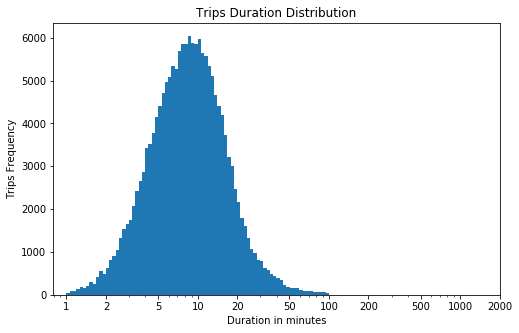

```python
# Trips Duration Distribution
col = df_clean['duration_min']
colname = 'duration_min'
plot_log(df_clean,col,colname,'Duration in minutes','Trips Frequency','Trips Duration Distribution')
```

## (Rush hours)

> at 17 and 08 there are rush hours when people going and leaving Work

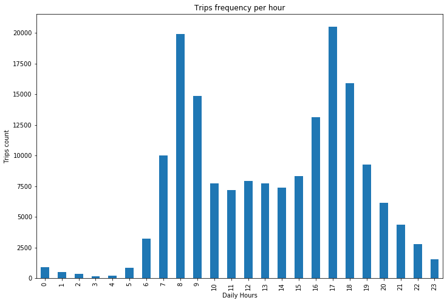

```python
# Rush hours
plt.figure(figsize=[12, 8]);
df_clean.start_hour_day.value_counts(sort=False).plot.bar()
plt.xlabel('Daily Hours')
plt.ylabel('Trips count')
plt.title('Trips frequency per hour');
```

## (changes in duration over each Hour)

> Trips from 10 to 16 usualy have higher Duration

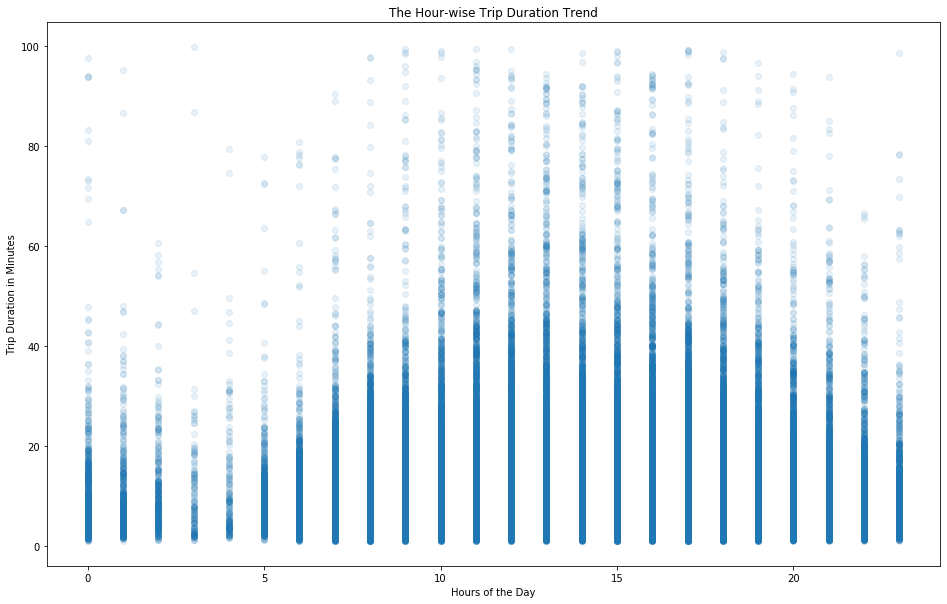

```python
# Here we plot and track the changes in duration over each Hour.

plt.figure(figsize = [16,10]) # Makes the figure enlarged for better visualization
plt.scatter(data = df_clean , x = 'start_hour_day' , y = 'duration_min' , alpha = 0.1 )
plt.title('The Hour-wise Trip Duration Trend')
plt.xlabel('Hours of the Day')
plt.ylabel('Trip Duration in Minutes')
plt.show();
```

## (Trips Duration vs Days of the week)

> Trips duration increase on weekends

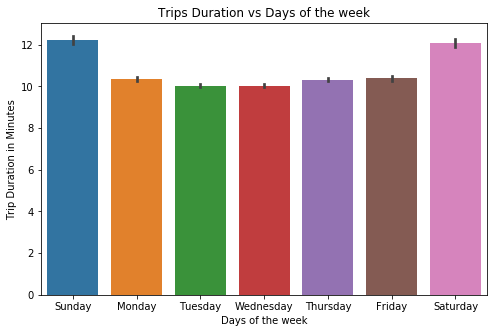

```python
days = ['Sunday','Monday','Tuesday','Wednesday','Thursday','Friday','Saturday']
plt.figure(figsize=[8, 5]);
sb.barplot(x='start_day_week', y='duration_min', data=df_clean,order = days );
plt.title('Trips Duration vs Days of the week')
plt.xlabel('Days of the week')
plt.ylabel('Trip Duration in Minutes')
plt.show();
```

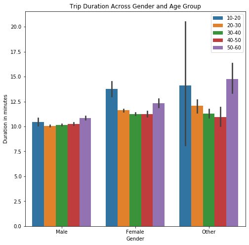

```python
# create bar plot on gender versus duration on levels of the age group variable
plt.figure(figsize = [8, 8])

ax = sb.barplot(x='member_gender', y = 'duration_min', hue='Age_group', data=df_clean.sort_values(by= 'Age_group'))
plt.title('Trip Duration Across Gender and Age Group')
plt.xlabel('Gender')
plt.ylabel('Duration in minutes')
leg = ax.legend()
```

```python
!jupyter nbconvert FordGoBike_slide_deck.ipynb --to slides --post serve --template output_toggle
```